# 06_02_Maps_Choropleth

### 4.1 Palette `YlOrRd`

**Instead of using `colorFactor()` to build the scale we use `colorNumeric()`**, because now we are dealing with a continuous numerical variable and we want to build a continuous scale of colors (like when we used a gradeint scale in ggplot). The function takes the same arguments:

- `palette`: this argument specified the colors to map the data to. It can take **one of several forms**:
  - The name of a preset palette from the `RColorBrewer` package, e.g. `"RdYlBu"`, `"Accent"`, or `"Greens"`. These scales can be found on this [link](https://r-graph-gallery.com/38-rcolorbrewers-palettes.html). We will also see them how to add to them within R
  - The full name of a viridis palette: `"viridis"`, `"magma"`, `"inferno"`, or `"plasma"`. These can be found on this [link](https://waldyrious.net/viridis-palette-generator/)
  - A character vector specifying colors, e.g. `c("#000000", "#0000FF", "#FFFFFF"), topo.colors(10)`.
- `domain`: tellls the color function the range of input values. We will pass `NULL` here and the palette function will infer the range everytime we use it in a map.

```r
# Define a scale appropriate for a continuous variable
# with continuous colors.
contpal <- colorNumeric(palette = "YlOrRd",
                        domain = NULL)

leaflet(mad_districts) %>%

    # Loads the background map
    addTiles() %>%

    # Loads the polygons
    addPolygons(

      # Adds thick line for polygon boundaries
      stroke = TRUE,

      smoothFactor = 0.3,

      # Sets width value for polygon boundaries
      weight = 2,

      # Changes default color of boundaries and fill
      color = "white",

      # Dashed pattern to the boundaries
      dashArray = "3",

      # Use the previously created color scale to fill the polygons
      # Note that name refers to the column avg_price in mad_districts@data,
      # which signals the average price per square meter in each district.
      fillColor =  ~contpal(avg_price),

      # Adjusts the transparecy of the fill color of the polygons
      fillOpacity = 0.7,

      # Shows label when hovering over the districts
      # The variable name referes to the name of the district
      # to be found in the dataframe mad_districts@data
      label = ~paste0(name, " - ", avg_price, " €/m2"),

      # Adds highlight as the moue hovers over
      highlightOptions = highlightOptions(
        weight = 4,
        color = "grey",
        dashArray = "",
        fillOpacity = 0.7,
        bringToFront = TRUE)
      ) %>%

    addLegend(pal = contpal,
              values = ~avg_price,
              opacity = 1.0)
```

[interactive chart not shown]

This results looks acceptale. Lets try as well the other proposed scale.

### 4.2 Palette `RdYlBu`

Note that we use the argument `reverse = TRUE` to ensure the colors are assigned properly to the low and high ends of the variable! I tried generating the graph and included reverse when I saw the colors were not properly assigned.

```r
# Define a scale appropriate for a continuous variable
# with continuous colors.
# NOTE THE ARGUMENT reverse = TRUE - to have colors appropriately
# allocated.
contpal <- colorNumeric(palette = "RdYlBu",
                        domain = NULL,
                        reverse = TRUE)

leaflet(mad_districts) %>%

    # Loads the background map
    addTiles() %>%

    # Loads the polygons
    addPolygons(

      # Adds thick line for polygon boundaries
      stroke = TRUE,

      smoothFactor = 0.3,

      # Sets width value for polygon boundaries
      weight = 2.5,

      # Changes default color of boundaries and fill
      color = "white",

      # Dashed pattern to the boundaries
      dashArray = "3",

      # Use the previously created color scale to fill the polygons
      # Note that name refers to the column avg_price in mad_districts@data,
      # which signals the average price per square meter in each district.
      fillColor =  ~contpal(avg_price),

      # Adjusts the transparecy of the fill color of the polygons
      fillOpacity = 0.7,

      # Shows label when hovering over the districts
      # The variable name referes to the name of the district
      # to be found in the dataframe mad_districts@data
      label = ~paste0(name, " - ", avg_price, " €/m2"),

      # Adds highlight as the moue hovers over
      highlightOptions = highlightOptions(
        weight = 4,
        color = "grey",
        dashArray = "",
        fillOpacity = 0.7,
        bringToFront = TRUE)
      ) %>%

    addLegend(pal = contpal,
              values = ~avg_price,
              opacity = 1.0)
```

[interactive chart not shown]

This also looks acceptable, but perhaps the lower blues are too dark. We can control this with some effort

### 4.3 Palette `RdYlBu` with less intense color endings

The function `brewer.pal` fron `RColorBrewer` returns the decimal colors for the scales in `RColorBrewer`. It returns a vector of Hexadecimal colors.

```r
# n = number of colors
# name = name of the scale
v_colors <- brewer.pal(n = 11, name = 'RdYlBu')
v_colors
```

```
 [1] "#A50026" "#D73027" "#F46D43" "#FDAE61" "#FEE090" "#FFFFBF" "#E0F3F8"
 [8] "#ABD9E9" "#74ADD1" "#4575B4" "#313695"
```

We can then go and visualize those colors with the library `scales`

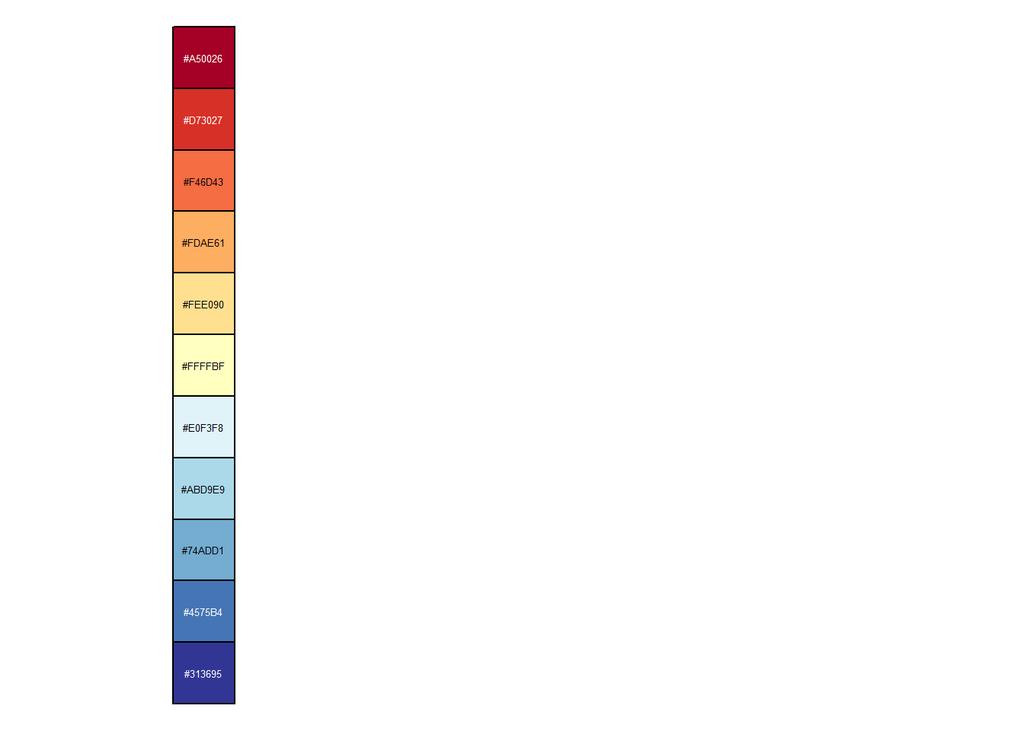

```r
scales::show_col(v_colors,
                 cex_label = 0.4,
                 ncol = 1,
                 labels = TRUE)
```

Using `rev()` we can reverse the vector and flip the colors:

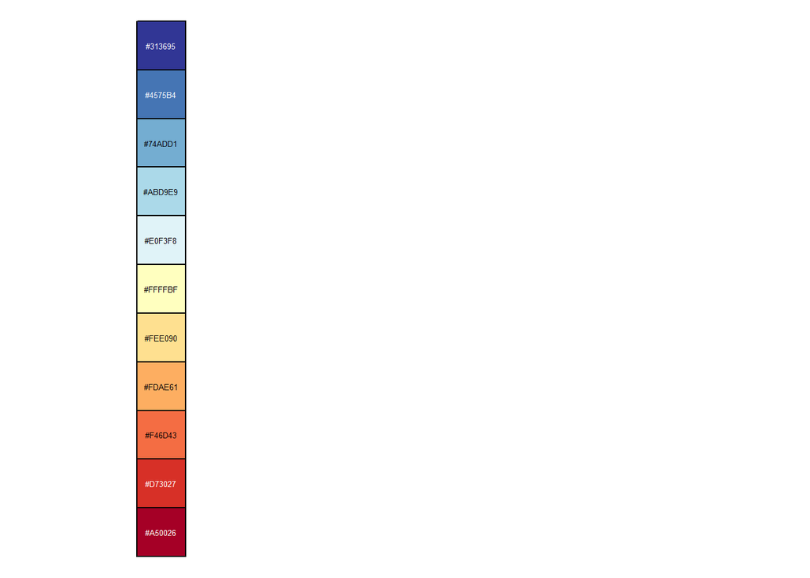

```r
scales::show_col(rev(v_colors),
                 cex_label = 0.4,
                 ncol = 1,
                 labels = TRUE)
```

We want to:

1. Reduce the number of colors in the scale.
2. While keeping the midpoint.

We can attain this reducing the colors in steps of 2. Lets try this:

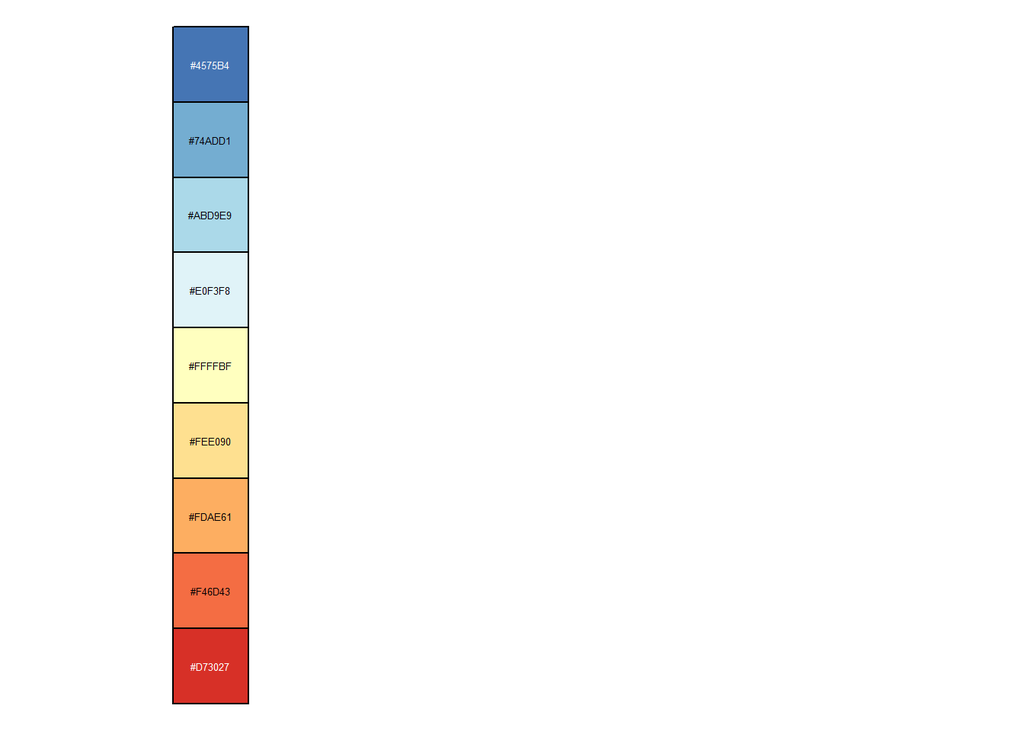

```r
v_colors <- brewer.pal(n = 9, name = 'RdYlBu')
scales::show_col(rev(v_colors),
                 cex_label = 0.4,
                 ncol = 1,
                 labels = TRUE)
```

We can now use this vector of colors to define a scale for our map using `color numeric`

```r
v_colors <- rev(brewer.pal(9, "RdYlBu"))
contpal <- colorNumeric(palette = v_colors,
                        domain = NULL)

leaflet(mad_districts) %>%

    # Loads the background map
    addTiles() %>%

    # Loads the polygons
    addPolygons(

      # Adds thick line for polygon boundaries
      stroke = TRUE,

      smoothFactor = 0.3,

      # Sets width value for polygon boundaries
      weight = 2,

      # Changes default color of boundaries and fill
      color = "white",

      # Dashed pattern to the boundaries
      dashArray = "3",

      # Use the previously created color scale to fill the polygons
      # Note that name refers to the column avg_price in mad_districts@data,
      # which signals the average price per square meter in each district.
      fillColor =  ~contpal(avg_price),

      # Adjusts the transparecy of the fill color of the polygons
      fillOpacity = 0.7,

      # Shows label when hovering over the districts
      # The variable name referes to the name of the district
      # to be found in the dataframe mad_districts@data
      label = ~paste0(name, " - ", avg_price, " €/m2"),

      # Adds highlight as the moue hovers over
      highlightOptions = highlightOptions(
        weight = 4,
        color = "grey",
        dashArray = "",
        fillOpacity = 0.7,
        bringToFront = TRUE)
      ) %>%

    addLegend(pal = contpal,
              values = ~avg_price,
              opacity = 1.0)
```

[interactive chart not shown]

To my eyes, in this case, the previous result looks better, particularly because it reflects bettwe the high end prices of the district *Salamanca*.

## 5. Color the polygons following the average prices (continuous variable) but making it discrete using the quantiles of the variable.

This can be done using the function `colorQuantile()` to generate a color scale based on the quantiles automatically.

```r
# The variable n specifies the number of quantiles to be generated
qpal <- colorQuantile(palette = "YlOrRd",
                      domain = NULL,
                      n = 8)

leaflet(mad_districts) %>%

    # Loads the background map
    addTiles() %>%

    # Loads the polygons
    addPolygons(

      # Adds thick line for polygon boundaries
      stroke = TRUE,

      smoothFactor = 0.3,

      # Sets width value for polygon boundaries
      weight = 2.5,

      # Changes default color of boundaries and fill
      color = "white",

      # Dashed pattern to the boundaries
      dashArray = "3",

      # Use the previously created color scale to fill the polygons
      # Note that name refers to the column avg_price in mad_districts@data,
      # which signals the average price per square meter in each district.
      fillColor =  ~qpal(avg_price),

      # Adjusts the transparecy of the fill color of the polygons
      fillOpacity = 0.7,

      # Shows label when hovering over the districts
      # The variable name referes to the name of the district
      # to be found in the dataframe mad_districts@data
      label = ~paste0(name, " - ", avg_price, " €/m2"),

      # Adds highlight as the moue hovers over
      highlightOptions = highlightOptions(
        weight = 4,
        color = "grey",
        dashArray = "",
        fillOpacity = 0.7,
        bringToFront = TRUE)
      ) %>%

    addLegend(pal = qpal,
              values = ~avg_price,
              opacity = 1.0)
```

[interactive chart not shown]